# Practical Machine Learning Project - Report

Harkishan Grewal

12/31/2020

### Load Required Libraries

```r
library(caret)
```

```r
library(rpart)
library(rpart.plot)
library(RColorBrewer)
library(rattle)
library(randomForest)
library(knitr)
```

# Background

Using devices such as Jawbone Up, Nike FuelBand, and Fitbit it is now possible to collect a large amount of data about personal activity relatively inexpensively. These type of devices are part of the quantified self movement – a group of enthusiasts who take measurements about themselves regularly to improve their health, to find patterns in their behavior, or because they are tech geeks. One thing that people regularly do is quantify how much of a particular activity they do, but they rarely quantify how well they do it.

In this project, I will use the data from accelerometers on the belt, forearm, arm, and dumbell of 6 participants. The participants were asked to perform barbell lifts correctly and incorrectly in 5 different ways. More information is available from the website here: http://web.archive.org/web/20161224072740/http:/groupware.les.inf.puc-rio.br/har (see the section on the Weight Lifting Exercise Dataset).

# Data

The training data for this project are available here: https://d396qusza40orc.cloudfront.net/predmachlearn/pml-training.csv

The test data are available here: https://d396qusza40orc.cloudfront.net/predmachlearn/pml-testing.csv

The data for this project come from this source: http://web.archive.org/web/20161224072740/http:/groupware.les.inf.puc-rio.br/har. Please cite the source if their data is used.

## Data Preprocessing

### Download the Data

Here I download the data, if it is not downloaded already.

```r
trainUrl <-"https://d396qusza40orc.cloudfront.net/predmachlearn/pml-training.csv"
testUrl <- "https://d396qusza40orc.cloudfront.net/predmachlearn/pml-testing.csv"
trainFile <- "./pml-training.csv"
testFile  <- "./pml-testing.csv"

# Download training data file if not downloaded already
if (!file.exists(trainFile)) {
  download.file(trainUrl, destfile=trainFile, method="curl")
}

# Download testing data file if not downloaded already
if (!file.exists(testFile)) {
  download.file(testUrl, destfile=testFile, method="curl")
}
```

### Read the Data

After downloading the data from the data source, I read the data from the two files.

```r
trainRaw <- read.csv("./pml-training.csv")
testRaw <- read.csv("./pml-testing.csv")
```

As shown below, the training dataset has 19622 observations and 160 variables. The testing dataset has 20 observations and 160 variables.

```r
dim(trainRaw)
```

```
## [1] 19622   160
```

```r
dim(testRaw)
```

```
## [1]  20 160
```

### Clean the Data

First, I remove the variables containing missing values.

```r
trainData <- trainRaw[, colSums(is.na(trainRaw)) == 0]
testRaw <- testRaw[, colSums(is.na(testRaw)) == 0]
```

The dimensions of the datasets after removing variables with missing values are shown below.

```r
dim(trainData)
```

```
## [1] 19622    93
```

```r
dim(testRaw)
```

```
## [1] 20 60
```

Next, I remove the first seven variables because they have little impact on **classe**.

```r
trainData <- trainData[, -c(1:7)]
testRaw <- testRaw[, -c(1:7)]
```

The dimensions of the datasets after removing low impact variables are shown below.

```r
dim(trainData)
```

```
## [1] 19622    86
```

```r
dim(testRaw)
```

```
## [1] 20 53
```

Lastly, I remove near-zero-variance (NZV) variables from data.

```r
nzv <- nearZeroVar(trainData)
trainData <- trainData[, -nzv]
```

The dimensions of the datasets after removing near-zero-variance variables are shown below.

```r
dim(trainData)
```

```
## [1] 19622    53
```

### Split the Data

```r
set.seed(2021)
train <- createDataPartition(trainData$classe, p = 0.7, list = FALSE)
trainData <- trainData[train, ]
testData <- trainData[-train, ]
```

The dimensions of the datasets after the split are shown below.

```r
dim(trainData)
```

```
## [1] 13737    53
```

```r
dim(testData)
```

```
## [1] 4123   53
```

## Build a Model

I will use decision trees, random forests, and generalized boosted model algorithms to build a model.

### Decision Trees Model

Now, I create a decision tree model and plot the tree as a dendogram.

[figure not shown]

```r
dtm <- rpart(classe ~ ., data = trainData, method = "class")
fancyRpartPlot(dtm)
```

Next, I test the classification tree model on the test data.

```r
predictDTM <- predict(dtm, testData, type = "class")
cmDTM <- confusionMatrix(predictDTM, as.factor(testData$classe))
cmDTM
```

```
## Confusion Matrix and Statistics
##
##           Reference
## Prediction    A    B    C    D    E
##          A 1035  116    9   14   11
##          B   41  486   42   59   74
##          C   26  104  569  108   95
##          D   38   72   50  400   42
##          E   16   45   44   65  562
##
## Overall Statistics
##
##                Accuracy : 0.7402
##                  95% CI : (0.7266, 0.7536)
##     No Information Rate : 0.2804
##     P-Value [Acc > NIR] : < 2.2e-16
##
##                   Kappa : 0.6716
##
##  Mcnemar's Test P-Value : < 2.2e-16
##
## Statistics by Class:
##
##                      Class: A Class: B Class: C Class: D Class: E
## Sensitivity            0.8953   0.5905   0.7969  0.61920   0.7168
## Specificity            0.9494   0.9345   0.9023  0.94190   0.9491
## Pos Pred Value         0.8734   0.6923   0.6308  0.66445   0.7678
## Neg Pred Value         0.9588   0.9015   0.9550  0.93013   0.9345
## Prevalence             0.2804   0.1996   0.1732  0.15668   0.1902
## Detection Rate         0.2510   0.1179   0.1380  0.09702   0.1363
## Detection Prevalence   0.2874   0.1703   0.2188  0.14601   0.1775
## Balanced Accuracy      0.9224   0.7625   0.8496  0.78055   0.8330
```

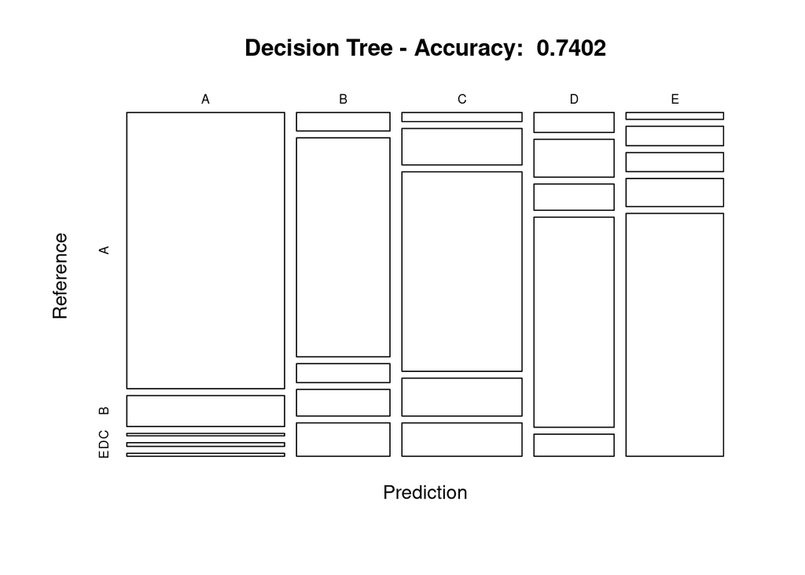

```r
plot(cmDTM$table, col = cmDTM$byClass,
     main = paste("Decision Tree - Accuracy: ", round(cmDTM$overall['Accuracy'], 4)))
```

### Random Forest

Now, I create a random forest model.

```r
trainData$classe = factor(trainData$classe)
rf <- randomForest(classe ~ ., data = trainData)
predictRF <- predict(rf, testData, type = "class")
cmRF <- confusionMatrix(predictRF, as.factor(testData$classe))
cmRF
```

```
## Confusion Matrix and Statistics
##
##           Reference
## Prediction    A    B    C    D    E
##          A 1156    0    0    0    0
##          B    0  823    0    0    0
##          C    0    0  714    0    0
##          D    0    0    0  646    0
##          E    0    0    0    0  784
##
## Overall Statistics
##
##                Accuracy : 1
##                  95% CI : (0.9991, 1)
##     No Information Rate : 0.2804
##     P-Value [Acc > NIR] : < 2.2e-16
##
##                   Kappa : 1
##
##  Mcnemar's Test P-Value : NA
##
## Statistics by Class:
##
##                      Class: A Class: B Class: C Class: D Class: E
## Sensitivity            1.0000   1.0000   1.0000   1.0000   1.0000
## Specificity            1.0000   1.0000   1.0000   1.0000   1.0000
## Pos Pred Value         1.0000   1.0000   1.0000   1.0000   1.0000
## Neg Pred Value         1.0000   1.0000   1.0000   1.0000   1.0000
## Prevalence             0.2804   0.1996   0.1732   0.1567   0.1902
## Detection Rate         0.2804   0.1996   0.1732   0.1567   0.1902
## Detection Prevalence   0.2804   0.1996   0.1732   0.1567   0.1902
## Balanced Accuracy      1.0000   1.0000   1.0000   1.0000   1.0000
```

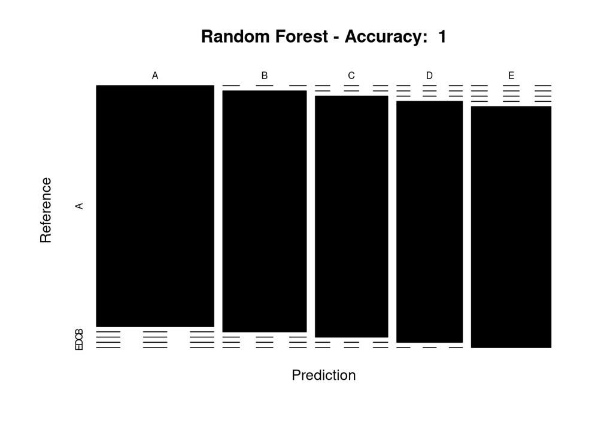

```r
plot(cmRF$table, col = cmRF$byClass,
     main = paste("Random Forest - Accuracy: ", round(cmRF$overall['Accuracy'], 4)))
```

### Generalized Boosted Regression

Lastly, I create a generalized boosted regression model.

```r
control <- trainControl(method = "repeatedcv", number = 5, repeats = 1)
gbm <- train(classe ~ ., data = trainData, method = "gbm", trControl = control,
                 verbose = FALSE)

predictGBM <- predict(gbm, testData)
cmGBM <- confusionMatrix(predictGBM, as.factor(testData$classe))
cmGBM
```

```
## Confusion Matrix and Statistics
##
##           Reference
## Prediction    A    B    C    D    E
##          A 1146   25    0    1    0
##          B    6  784   16    1    3
##          C    1   14  692   13    6
##          D    3    0    5  628    7
##          E    0    0    1    3  768
##
## Overall Statistics
##
##                Accuracy : 0.9745
##                  95% CI : (0.9693, 0.9791)
##     No Information Rate : 0.2804
##     P-Value [Acc > NIR] : < 2.2e-16
##
##                   Kappa : 0.9678
##
##  Mcnemar's Test P-Value : NA
##
## Statistics by Class:
##
##                      Class: A Class: B Class: C Class: D Class: E
## Sensitivity            0.9913   0.9526   0.9692   0.9721   0.9796
## Specificity            0.9912   0.9921   0.9900   0.9957   0.9988
## Pos Pred Value         0.9778   0.9679   0.9532   0.9767   0.9948
## Neg Pred Value         0.9966   0.9882   0.9935   0.9948   0.9952
## Prevalence             0.2804   0.1996   0.1732   0.1567   0.1902
## Detection Rate         0.2780   0.1902   0.1678   0.1523   0.1863
## Detection Prevalence   0.2843   0.1965   0.1761   0.1560   0.1872
## Balanced Accuracy      0.9913   0.9724   0.9796   0.9839   0.9892
```

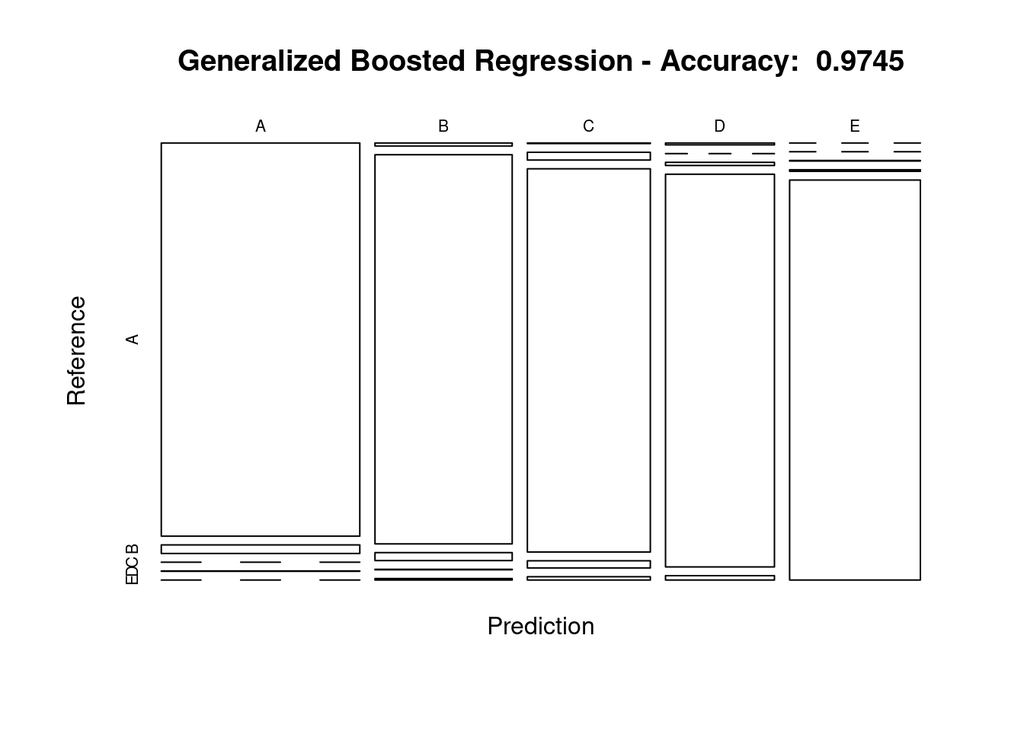

```r
plot(cmGBM$table, col = cmGBM$byClass,
     main = paste("Generalized Boosted Regression - Accuracy: ", round(cmGBM$overall['Accuracy'], 4)))
```

## Test Data

```r
predict <- predict(rf, testRaw, type = "class")
predict
```

```
##  1  2  3  4  5  6  7  8  9 10 11 12 13 14 15 16 17 18 19 20
##  B  A  B  A  A  E  D  B  A  A  B  C  B  A  E  E  A  B  B  B
## Levels: A B C D E
```